# Final Project Draft

Lindsey Fisher

11/16/2020

## An Analysis of US Enenrgy Related Consumption and Emmisions Data

##### Group Members: Lindsey Fisher(2020 Data), Param Bhandare(2015 Data), Yunqing Xiao(2011 Data)

### Introduction

We were interested in looking at something environmentally related, so we chose US energy consumption and emissions. We chose two reports from the Annual Energy Outlook (AEO) report from the US Energy Information Administration. We chose to look at the AEO published in 2011, and the AEO published in 2020. We chose these reports because they are a decade apart and will serve as a comparison to see if we have reduced emissions and consumption overall. We believe there is a lot of relationships between variables to be examined and uncovered. We are interested in relationships between the variables in each of the data sets as well as comparing the variables across the separate data sets to look for trends. We hope to use this analysis to locate key areas where the US is doing well in reducing emissions and consumption and areas where we need to focus on improvement. We hope to assess the validity of the AEOs projections by comparing the future projections in the 2011 report to the observed measures from the 2020 report.

### Background

Emissions Data: The emissions data measures outputs into the atmosphere in Million Metric Ton CO2 Equivalents. This is a measure of global warming potential. CO2 is a well know gas that traps heat in the atmosphere, however, there are other gasses which trap heat at a much higher magnitude. The measurement is called CO2 equivalents because it measures the amount of total global warming potential as a factor of the magnitude of one CO2 molecules warming potential. It is separated out by sector: residential, commercial, industrial, transportation, and electric power. As well as by fuel source: petroleum, natural gas, coal, and electric power generation, and an “other” category. The data was collected by the U.S Environmental Information Administration and is published on their website (https://www.eia.gov/outlooks/aeo/data) for public viewing. The projections were made using the AEO National Energy Modeling System.

Consumption Data: The consumption data measures how much energy was used in units of Quads. A Quad is a unit of energy equal to 10¹⁵ British Thermal Units, or 1.055 × 10¹⁸ joules in SI units. The US Department of Energy adopted the use of quads as their unit of energy use measurement for national and international reports. The consumption data reports energy consumption by sector and power source. Sectors include residential, commercial, industrial, transportation, electric power, and delivered energy. The energy sources for consumption are more complex and vary with in each sector. The data was collected by the U.S Environmental Information Administration and is published on their website (https://www.eia.gov/outlooks/aeo/data) for public viewing. The projections were made using the AEO National Energy Modeling System.

## **(1) How do total emissions vary by year?**

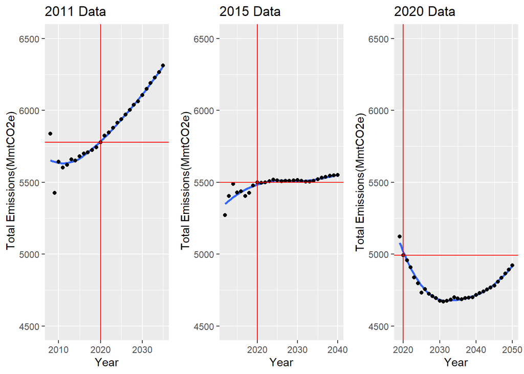

## **(2) Which fuel source is the greatest emissions contributer per year? How many million metric tons of CO2e are output by the greatest contributer?**

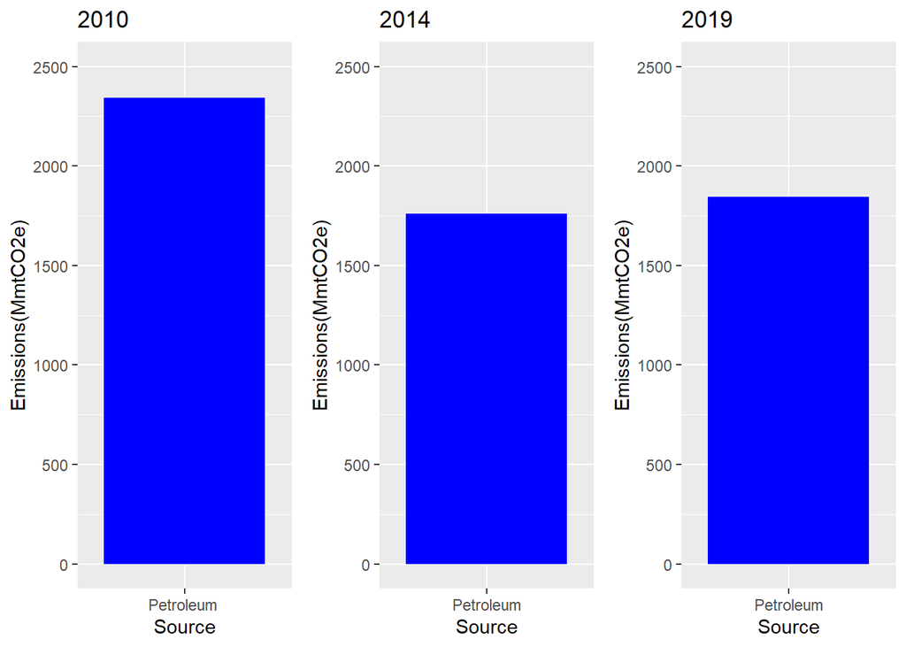

## **(3)Which sector produces the most emissions? Does this vary by which year the outlook report is pulished?**

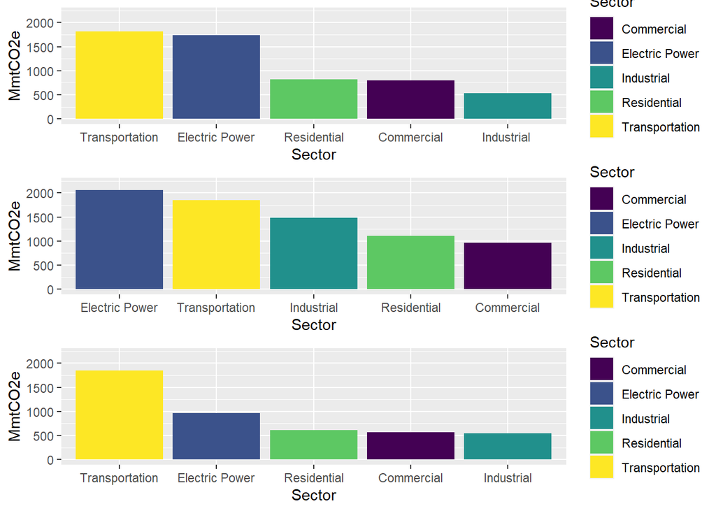

## **(4)Looking at total emissions by fuel source, which is the greatest contributor? Which fuel source has the greatest projected consumption?**

### Which fuel source is the greatest contribuer to emmisions?

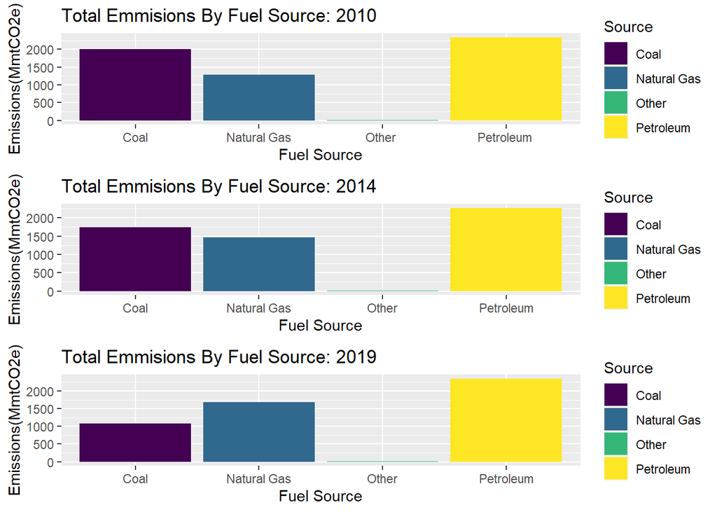

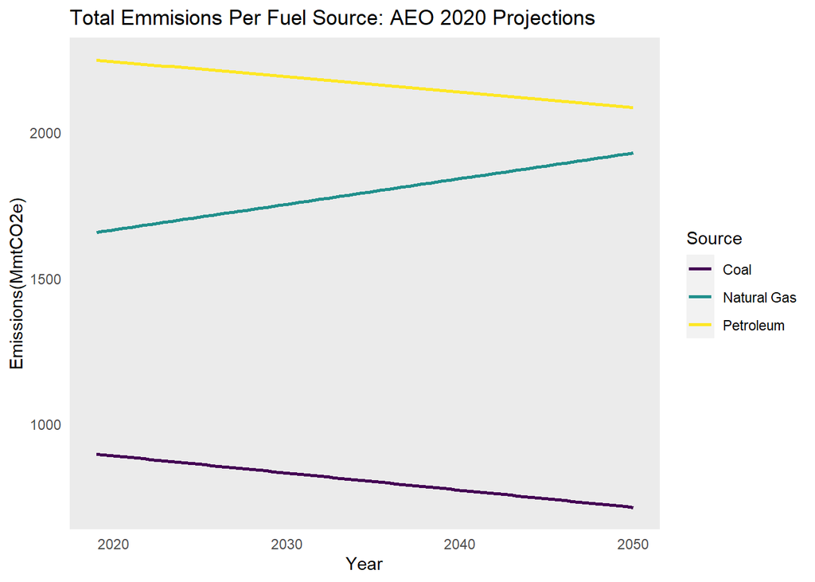

## **(5) Which sector uses the most renewables? Which uses the most non-renewables?**

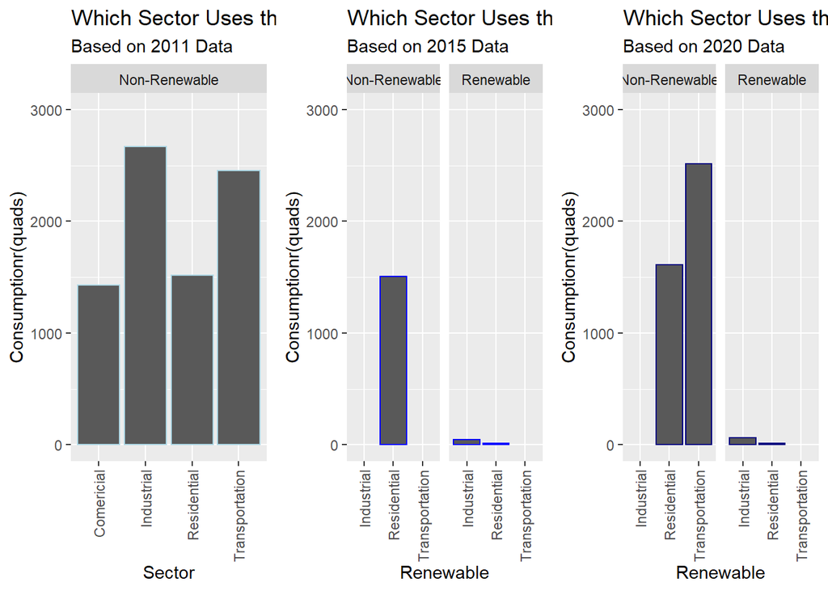

## **(6) Which energy source is utilized the most in each sector?**

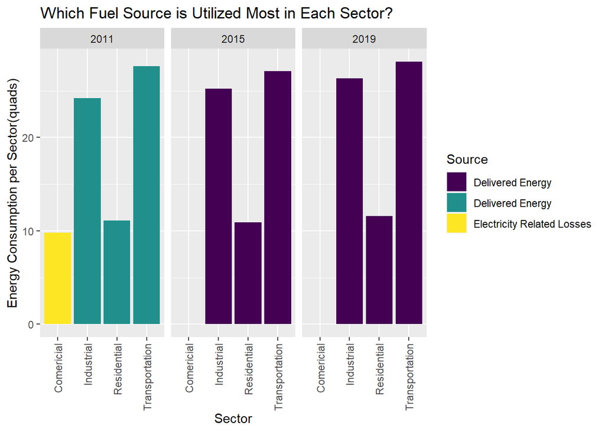

## **(7)Which sector has the highest growth rate for each fuel source?**

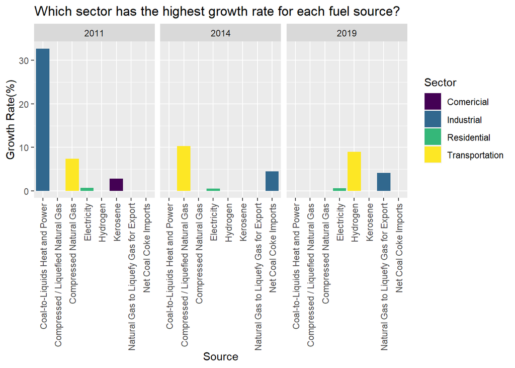

## **(8) Which energy source has the highest growth rate over all?**

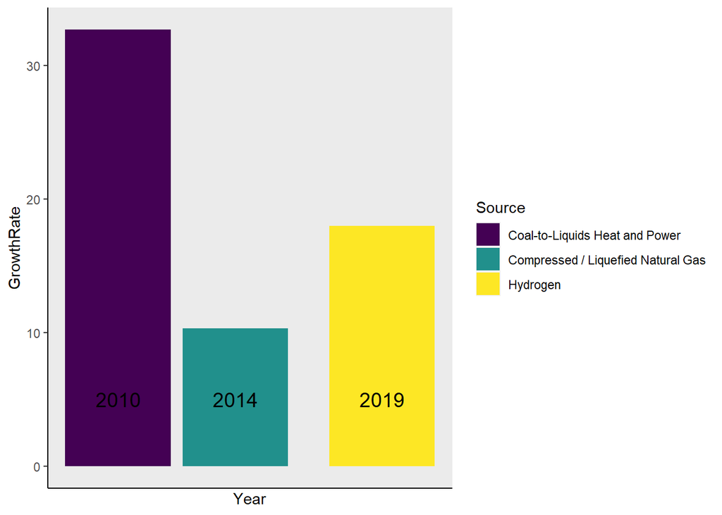

## **(9)How do energy consumption projection trends change based on the year the report was published?**

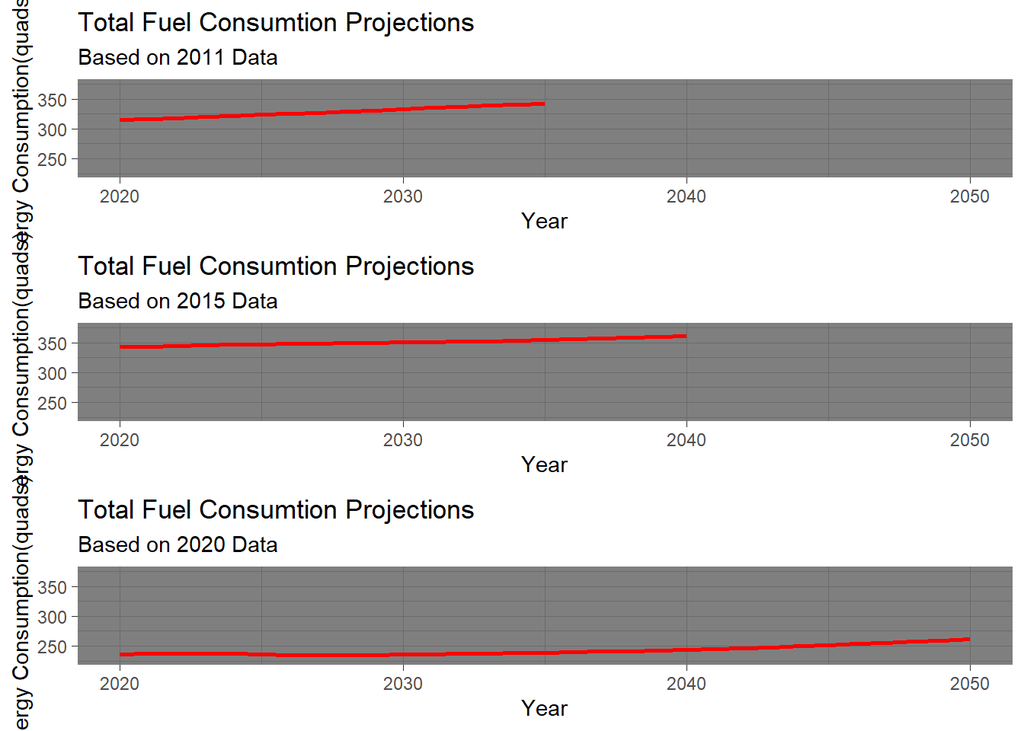

## **(10).Compare projections for 2019 agaisnt to actual measures in 2019.**

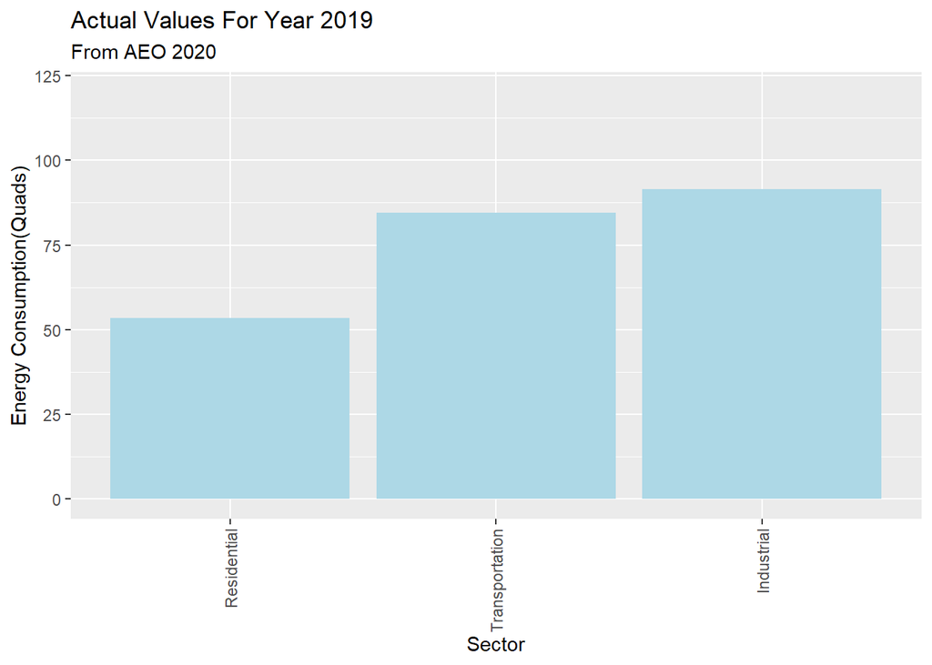

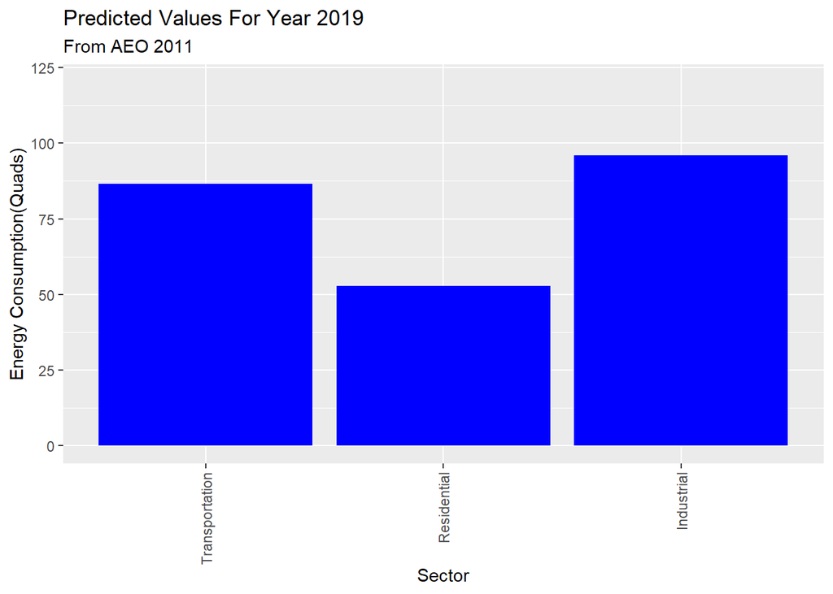

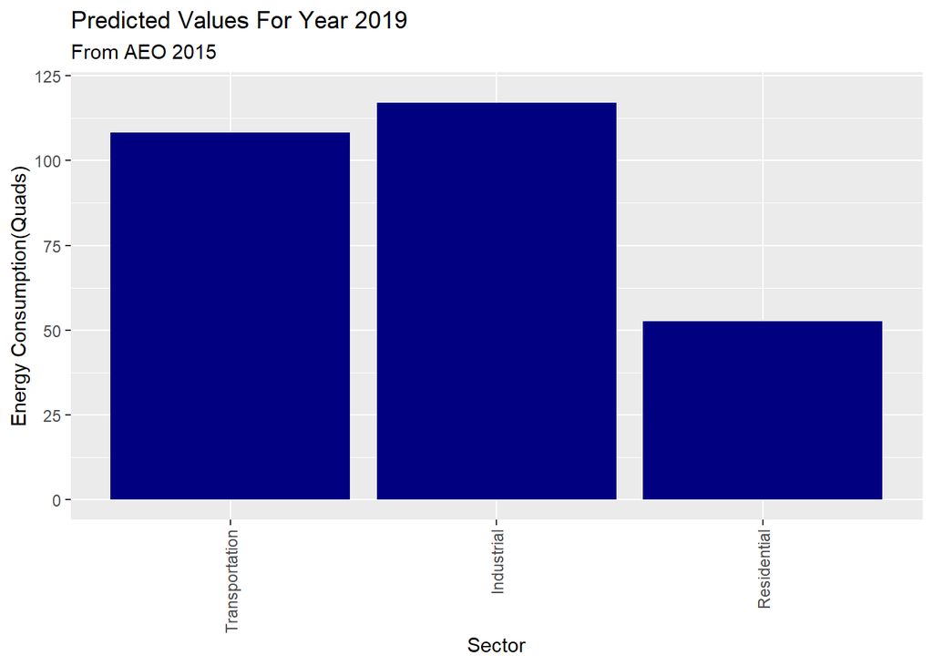

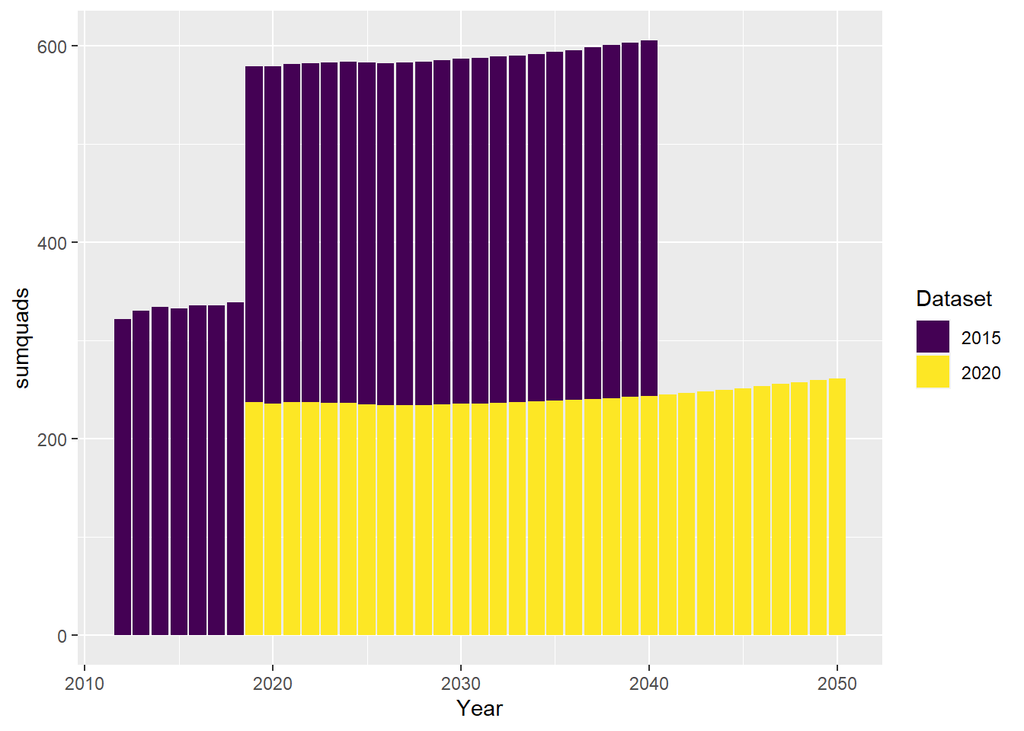

```r
ConsumptionByYear2015 <- ConsumptionByYear2015 %>%
    mutate(Dataset = "2015")
ConsumptionByYear2020 <- ConsumptionByYear2020 %>%
    mutate(Dataset = "2020")
consumptions_2015_2020_combined <- bind_rows(ConsumptionByYear2015, ConsumptionByYear2020)
sourcetopn2015 <- sourcetopn2015 %>%
    mutate(Dataset = "2015")
sourcetopn2020 <- sourcetopn2020 %>%
    mutate(Dataset = "2020")
emission_2015_2020_combined <- bind_rows(sourcetopn2015, sourcetopn2020)

ggplot(consumptions_2015_2020_combined, aes(Year, sumquads, fill = Dataset)) +
geom_col()
```

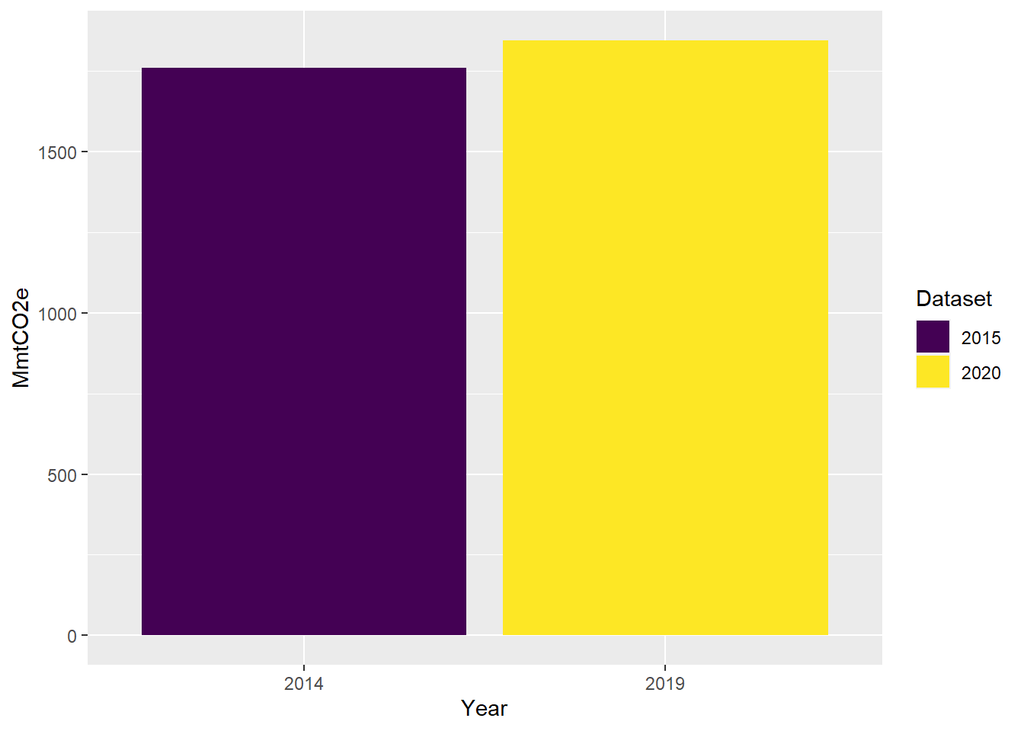

```r
ggplot(emission_2015_2020_combined, aes(Year, MmtCO2e, fill = Dataset)) +
    geom_col()
```

### Discussion

The datasets for 2015 energy outlook seems to be slightly inconsistent with format and depth of projections with other datasets. This is not too much of a shortcoming, but as analysts, it does leave us guessing for the verification of some of the prior projections in later datasets within a single dataset. Additionally, the outlook is made during the fiscal year that the outlook is released, so only the previous few years will be accurate. This requires more data to be obtained, which in turn requires more standardization between the format of each dataset. Perhaps, given the previous years data-sets and actual values, a match between the mesh of datas that are equal could come handy. And to test performance even further, a whole parity chart could be made between different datasets actual performance and projected performance.

Further analysis can be made on specific governmental body’s policy performance, specifically around the time period they are made in tandem to the associated energy outlook data sets. Similarly, new data can be collected regarding this.

Conclusively, it appears Americans are doing a very good job on curbing emissions when considering the 2015 and 2020 dataset. Consumption is still there, but it is highly unlikely an increasing population will decrease their consumption of energy unless several billions of technology’s source of energy is changed to a more modern source, this also requiring a change in the technology itself.